# MLF_LogisticRegression_fromScratch

Importing required libraries and modules.

```python
import numpy as np
import pandas as pd

from sklearn.metrics import accuracy_score, precision_score, recall_score, f1_score
from sklearn.metrics import confusion_matrix, ConfusionMatrixDisplay
from sklearn.metrics import roc_curve, RocCurveDisplay, roc_auc_score, log_loss
```

```python
import matplotlib.pyplot as plt
import seaborn as sns
```

Importing dataset from UC Irvine Machine Learning Repository.

The dataset can be found in the following link.

https://archive.ics.uci.edu/dataset/244/fertility

Directly importing the *'Fertility'* dataset using UC Irvine Machine Learning Repository's API.

```python
!pip install ucimlrepo
```

```python
from ucimlrepo import fetch_ucirepo

# fetch dataset
fertility = fetch_ucirepo(id=244)

# data (as pandas dataframes)
X_df = fertility.data.features
y_df = fertility.data.targets

# metadata
print(fertility.metadata)

# variable information
print(fertility.variables)
```

```
{'uci_id': 244, 'name': 'Fertility', 'repository_url': 'https://archive.ics.uci.edu/dataset/244/fertility', 'data_url': 'https://archive.ics.uci.edu/static/public/244/data.csv', 'abstract': '100 volunteers provide a semen sample analyzed according to the WHO 2010 criteria. Sperm concentration are re…
                    name     role         type demographic description units  \
0                 season  Feature   Continuous        None        None  None
1                    age  Feature      Integer         Age        None  None
2         child_diseases  Feature       Binary        None        None  None
3               accident  Feature       Binary        None        None  None
4  surgical_intervention  Feature       Binary        None        None  None
5            high_fevers  Feature  Categorical        None        None  None
6                alcohol  Feature  Categorical        None        None  None
7                smoking  Feature  Categorical        None        None  None
8            hrs_sitting  Feature      Integer        None        None  None
9              diagnosis   Target       Binary        None        None  None

  missing_values
0             no
1             no
2             no
3             no
4             no
5             no
6             no
7             no
8             no
9             no
```

Taking a glance at the dataset.

```python
X_df.head()
```

|  | season | age | child_diseases | accident | surgical_intervention | high_fevers | alcohol | smoking | hrs_sitting |
| --- | --- | --- | --- | --- | --- | --- | --- | --- | --- |
| 0 | -0.33 | 0.69 | 0 | 1 | 1 | 0 | 0.8 | 0 | 0.88 |
| 1 | -0.33 | 0.94 | 1 | 0 | 1 | 0 | 0.8 | 1 | 0.31 |
| 2 | -0.33 | 0.50 | 1 | 0 | 0 | 0 | 1.0 | -1 | 0.50 |
| 3 | -0.33 | 0.75 | 0 | 1 | 1 | 0 | 1.0 | -1 | 0.38 |
| 4 | -0.33 | 0.67 | 1 | 1 | 0 | 0 | 0.8 | -1 | 0.50 |

```python
y_df.head()
```

|  | diagnosis |
| --- | --- |
| 0 | N |
| 1 | O |
| 2 | N |
| 3 | N |
| 4 | O |

Converting dataframes to numpy arrays for ease of use in our Logistic Regression implementation from scratch.

```python
X = X_df.to_numpy()

y = y_df.diagnosis.replace({'N': 0, 'O': 1}).to_numpy()
```

Logistic Model

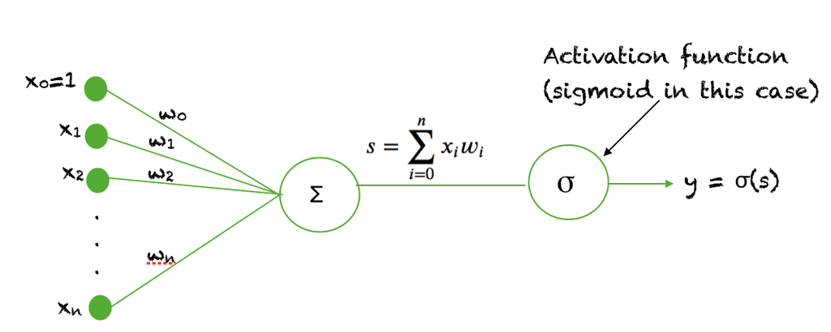

# Why The Sigmoid Function Is Important In Neural Networks?

If we use a linear activation function in a neural network, then this model can only learn linearly separable problems. However, with the addition of just one hidden layer and a sigmoid activation function in the hidden layer, the neural network can easily learn a non-linearly separable problem. Using a non-linear function produces non-linear boundaries and hence, the sigmoid function can be used in neural networks for learning complex decision functions.

The only non-linear function that can be used as an activation function in a neural network is one which is monotonically increasing. So for example, sin(x) or cos(x) cannot be used as activation functions. Also, the activation function should be defined everywhere and should be continuous everywhere in the space of real numbers. The function is also required to be differentiable over the entire space of real numbers.

Typically a back propagation algorithm uses gradient descent to learn the weights of a neural network. To derive this algorithm, the derivative of the activation function is required.

The fact that the sigmoid function is monotonic, continuous and differentiable everywhere, coupled with the property that its derivative can be expressed in terms of itself, makes it easy to derive the update equations for learning the weights in a neural network when using back propagation algorithm.

**Logistsic Regression implementation from scratch**

Sigmoid function

```python
def sigmoid(z):
    return 1 / (1 + np.exp(-z))
```

Hypothesis Function

```python
def hx(w, X):
  ones = np.ones((X.shape[0], 1))
  X_with_bias = np.hstack([ones, X])
  z = np.dot(X_with_bias, w)
  return sigmoid(z)
```

Cost Function - Binary Cross Entropy

```python
def cost(w, X, Y):
    y_pred = hx(w, X)
    return -np.mean(Y * np.log(y_pred) + (1 - Y) * np.log(1 - y_pred))
```

Gradient Descent

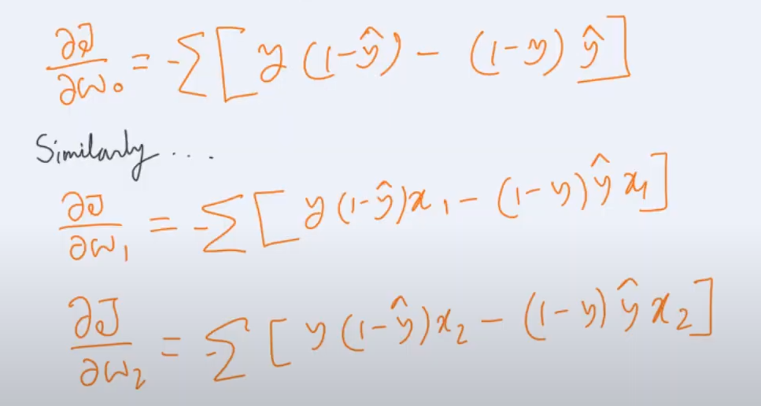

Gradient calculation function

```python
def grad(w, X, Y):
    y_pred = hx(w, X)
    errors = y_pred - Y
    ones = np.ones((X.shape[0], 1))
    X_with_bias = np.hstack([ones, X])
    gradients = np.dot(X_with_bias.T, errors) / Y.size
    return gradients
```

Gradient descent function

```python
def descent(w_init, lr, X, Y, max_iter=1000, tolerance=1e-6):
    w = w_init
    for j in range(max_iter):
        gradients = grad(w, X, Y)
        w_new = w - lr * gradients

        if np.linalg.norm(w_new - w, 2) < tolerance:
            print(f"Converged after {j+1} iterations.")
            return w_new

        w = w_new

        if (j + 1) % 100 == 0:
            print(f"Iteration {j+1}: Cost {cost(w, X, Y)}")
            print(f"weights: {w}")

    print("Max iterations reached without convergence.")
    return w
```

Results function

```python
def generate_results(y_test, y_pred, y_proba=None):

  print(f"Accuracy: {accuracy_score(y_test, y_pred)}")
  print(f"Precision: {precision_score(y_test, y_pred)}")
  print(f"Recall: {recall_score(y_test, y_pred)}")
  print(f"F1 Score: {f1_score(y_test, y_pred)}")

  cm = confusion_matrix(y_test, y_pred)
  auc = roc_auc_score(y_test, y_pred)

  print(f"\nAUC: {auc}")
  print(f"\nLog loss: {log_loss(y_test, y_pred)}\n")

  fpr, tpr, thresholds = roc_curve(y_test, y_proba if y_proba is not None else y_pred)

  fig, ax = plt.subplots(1, 2, figsize=(12, 6))

  ConfusionMatrixDisplay(confusion_matrix=cm).plot(ax=ax[0])
  ax[0].set_title('Confusion Matrix')

  roc_display = RocCurveDisplay(fpr=fpr, tpr=tpr)
  roc_display.plot(ax=ax[1])
  ax[1].plot([0, 1], [0, 1], color='green', linestyle='--')
  ax[1].set_title('ROC Curve')

  plt.tight_layout()
  plt.show()
```

Initializing Parameters

```python
w_init = np.zeros(X.shape[1] + 1)

lr = 0.01
```

Training the Model

```python
w_optimal = descent(w_init, lr, X, y, 1000, 1e-6)

print(f'\nOptimal weights after training Logistic Regression model:')
print(w_optimal)
```

```
Iteration 100: Cost 0.4354144569747552
weights: [-0.25213367  0.06214325 -0.16364031 -0.22027804 -0.12934375 -0.11664533
 -0.06819453 -0.21693991  0.09301912 -0.10129138]
Iteration 200: Cost 0.3798059970753205
weights: [-0.36956183  0.10632317 -0.23679483 -0.32026913 -0.19576786 -0.16247225
 -0.10838357 -0.32125459  0.13358173 -0.147873  ]
Iteration 300: Cost 0.36189020717787557
weights: [-0.4342601   0.14340965 -0.27464901 -0.37354977 -0.23816295 -0.18143329
 -0.13765424 -0.38159125  0.15516677 -0.17301437]
Iteration 400: Cost 0.35432965341921785
weights: [-0.47340047  0.17654133 -0.29543329 -0.40425669 -0.2690011  -0.18772299
 -0.16146321 -0.42064174  0.16806627 -0.18774766]
Iteration 500: Cost 0.3503795840111965
weights: [-0.4984162   0.20688017 -0.30680088 -0.42246229 -0.29340023 -0.1872079
 -0.18203867 -0.44793453  0.1763724  -0.19671612]
Iteration 600: Cost 0.3479050028352468
weights: [-0.51500724  0.23495813 -0.31256145 -0.43316069 -0.31386821 -0.18277927
 -0.20047005 -0.46821317  0.18204551 -0.20223478]
Iteration 700: Cost 0.34611759821097265
weights: [-0.5263383   0.26106513 -0.31482795 -0.43911656 -0.33178187 -0.17602981
 -0.21735719 -0.48410883  0.18614235 -0.20558894]
Iteration 800: Cost 0.3446938738939797
weights: [-0.53429279  0.28538639 -0.31485683 -0.44197446 -0.34795561 -0.16790146
 -0.233059   -0.4971863   0.18927683 -0.2075434 ]
Iteration 900: Cost 0.34348930626732527
weights: [-0.54004344  0.30805829 -0.31342988 -0.4427606  -0.36289615 -0.15897698
 -0.24780413 -0.50841954  0.19182272 -0.20857438]
Iteration 1000: Cost 0.3424337401350715
weights: [-0.54434237  0.32919307 -0.31104814 -0.44213641 -0.37693011 -0.14962702
 -0.26174597 -0.51843299  0.19401388 -0.20898728]
Max iterations reached without convergence.

Optimal weights after training Logistic Regression model:
[-0.54434237  0.32919307 -0.31104814 -0.44213641 -0.37693011 -0.14962702
 -0.26174597 -0.51843299  0.19401388 -0.20898728]
```

Testing the trained model / weights with the original data

```python
y_prob = hx(w_optimal, X)
y_pred = np.array([1 if prob > 0.5 else 0 for prob in y_prob])
```

Generating results

```
Accuracy: 0.88
Precision: 0.0
Recall: 0.0
F1 Score: 0.0

AUC: 0.5

Log loss: 4.325238406694059
```

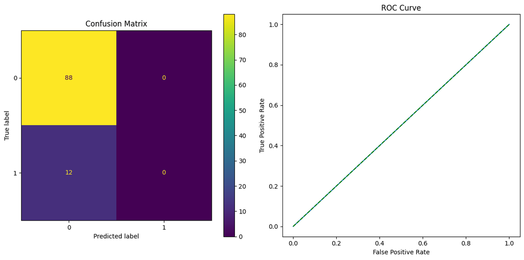

```python
# generate_results(y, y_pred, y_prob)
generate_results(y, y_pred)
```

**Logistic Regression implementation with Scikit learn library**

```python
from sklearn.linear_model import LogisticRegression

clf = LogisticRegression()
clf.fit(X, y)
clf.score(X, y)
```

```
0.88
```

```python
y_prob_clf = clf.predict_proba(X)
y_pred_clf = clf.predict(X)
```

```
Accuracy: 0.88
Precision: 0.0
Recall: 0.0
F1 Score: 0.0

AUC: 0.5

Log loss: 4.325238406694059
```

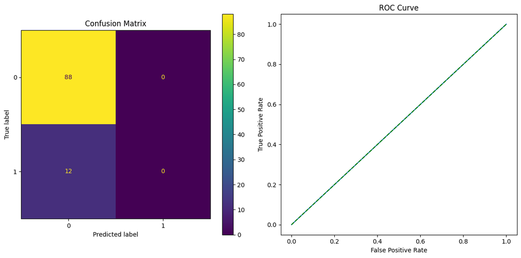

```python
# generate_results(y, y_pred_clf, y_prob_clf[:,1])
generate_results(y, y_pred_clf)
```

**Conclusion**

Both *Logistic Regression Scratch* and *Logistic Regression Scikit-Learn* implementations show exact same results and are consistent.

The consistency shows that the scratch implementation correctly mirrors the behivor of the scikit-learn library methods closely.

Both of them fail to accurately predict 'O' or 1 class [among 'N' and 'O' classes]. This is due to the dataset being highly imbalanced with very limited numbers of data with 'O' target class making the models unable to learn their patterns.